# Project 2: Modeling and Evaluation

CSE6242 - Data and Visual Analytics - Summer 2018 Due: Sunday, July 24, 2018 at 11:59 PM UTC-12:00 on T-Square

# Data

We will use the same dataset as Project 1: [`movies_merged`](https://s3.amazonaws.com/content.udacity-data.com/courses/gt-cs6242/project/movies_merged).

# Objective

Your goal in this project is to build a linear regression model that can predict the `Gross` revenue earned by a movie based on other variables. You may use R packages to fit and evaluate a regression model (no need to implement regression yourself). Please stick to linear regression, however.

# Instructions

You should be familiar with using an [RMarkdown](http://rmarkdown.rstudio.com) Notebook by now. Remember that you have to open it in RStudio, and you can run code chunks by pressing *Cmd+Shift+Enter*.

Please complete the tasks below and submit this R Markdown file (as **pr2.Rmd**) containing all completed code chunks and written responses, and a PDF export of it (as **pr2.pdf**) which should include the outputs and plots as well.

*Note that **Setup** and **Data Preprocessing** steps do not carry any points, however, they need to be completed as instructed in order to get meaningful results.*

# Setup

Same as Project 1, load the dataset into memory:

```r
library(splitstackshape)
```

[output not shown]

This creates an object of the same name (`movies_merged`). For convenience, you can copy it to `df` and start using it:

```r
colnames(df)
```

```
 [1] "Title"             "Year"              "Rated"             "Released"          "Runtime"           "Genre"
 [7] "Director"          "Writer"            "Actors"            "Plot"              "Language"          "Country"
[13] "Awards"            "Poster"            "Metascore"         "imdbRating"        "imdbVotes"         "imdbID"
[19] "Type"              "tomatoMeter"       "tomatoImage"       "tomatoRating"      "tomatoReviews"     "tomatoFresh"
[25] "tomatoRotten"      "tomatoConsensus"   "tomatoUserMeter"   "tomatoUserRating"  "tomatoUserReviews" "tomatoURL"
[31] "DVD"               "BoxOffice"         "Production"        "Website"           "Response"          "Budget"
[37] "Domestic_Gross"    "Gross"             "Date"
```

## Load R packages

Load any R packages that you will need to use. You can come back to this chunk, edit it and re-run to load any additional packages later.

```r
library(lubridate)
```

If you are using any non-standard packages (ones that have not been discussed in class or explicitly allowed for this project), please mention them below. Include any special instructions if they cannot be installed using the regular `install.packages('<pkg name>')` command.

**Non-standard packages used**: None

# Data Preprocessing

Before we start building models, we should clean up the dataset and perform any preprocessing steps that may be necessary. Some of these steps can be copied in from your Project 1 solution. It may be helpful to print the dimensions of the resulting dataframe at each step.

## 1. Remove non-movie rows

```r
dim(df)
```

```
[1] 40000    39
```

## 2. Drop rows with missing `Gross` value

Since our goal is to model `Gross` revenue against other variables, rows that have missing `Gross` values are not useful to us.

```r
dim(df)
```

```
[1] 4558   39
```

## 3. Exclude movies released prior to 2000

Inflation and other global financial factors may affect the revenue earned by movies during certain periods of time. Taking that into account is out of scope for this project, so let’s exclude all movies that were released prior to the year 2000 (you may use `Released`, `Date` or `Year` for this purpose).

```r
dim(df)
```

```
[1] 3366   40
```

## 4. Eliminate mismatched rows

*Note: You may compare the `Released` column (string representation of release date) with either `Year` or `Date` (numeric representation of the year) to find mismatches. The goal is to avoid removing more than 10% of the rows.*

```r
dim(df)
```

```
[1] 3284   40
```

## 5. Drop `Domestic_Gross` column

`Domestic_Gross` is basically the amount of revenue a movie earned within the US. Understandably, it is very highly correlated with `Gross` and is in fact equal to it for movies that were not released globally. Hence, it should be removed for modeling purposes.

```r
dim(df)
```

```
[1] 3284   39
```

## 6. Process `Runtime` column

```r
df$Runtime <- sapply(df$Runtime, parse_runtime)
```

[output not shown]

Perform any additional preprocessing steps that you find necessary, such as dealing with missing values or highly correlated columns (feel free to add more code chunks, markdown blocks and plots here as necessary).

## 7. Additional preprocessing - NA values

```r
df_numeric <- df[,sapply(df, function(x) is.numeric(x))]
df_numeric <- cbind(df$Title, df_numeric)
colnames(df_numeric)[1] <- "Title"
df_numeric$Year <- NULL
df_numeric$Date <- NULL
df_numeric$diff_year <- NULL
df_numeric$Metascore <- as.numeric(as.character(df$Metascore))
```

```
NAs introduced by coercion
```

```r
# check NA values in all column
print(sapply(df_numeric, function(x) sum(is.na(x))))
```

```
            Title           Runtime        imdbRating         imdbVotes       tomatoMeter      tomatoRating     tomatoReviews
                0                37                43                43               375               375               375
      tomatoFresh      tomatoRotten   tomatoUserMeter  tomatoUserRating tomatoUserReviews            Budget             Gross
              375               375               189               187                84                 0                 0
    Released_year         Metascore
                0               394
```

```r
# Remove rows where Runtime is not available
df_numeric <- df_numeric[!is.na(df_numeric$Runtime), ] # 37 rows removed
#df_NA <- na.omit(df)
#dim(df_NA)
# for real values features, replace NA with "average""
# tomatoRating and tomatoUserRating (5, 10 cols)
for(i in 2:ncol(df_numeric)){
  for (j in c(5,10)){
    df_numeric[is.na(df_numeric[,i]), j] <- mean(df_numeric[,i], na.rm = TRUE)
  }
}
# For the rest of NA values which are count replace them with "median""
for(i in 2:ncol(df_numeric)){
  df_numeric[is.na(df_numeric[,i]), i] <- median(df_numeric[,i], na.rm = TRUE)
}
# Re-check if no NA values in all column
print(sapply(df_numeric, function(x) sum(is.na(x))))
```

```
            Title           Runtime        imdbRating         imdbVotes       tomatoMeter      tomatoRating     tomatoReviews
                0                 0                 0                 0                 0                 0                 0
      tomatoFresh      tomatoRotten   tomatoUserMeter  tomatoUserRating tomatoUserReviews            Budget             Gross
                0                 0                 0                 0                 0                 0                 0
    Released_year         Metascore
                0                 0
```

**Note**: Do NOT convert categorical variables (like `Genre`) into binary columns yet. You will do that later as part of a model improvement task.

## Final preprocessed dataset

Report the dimensions of the preprocessed dataset you will be using for modeling and evaluation, and print all the final column names. (Again, `Domestic_Gross` should not be in this list!)

```r
print(colnames(df))
```

```
 [1] "Title"             "Year"              "Rated"             "Released"          "Runtime"           "Genre"
 [7] "Director"          "Writer"            "Actors"            "Plot"              "Language"          "Country"
[13] "Awards"            "Poster"            "Metascore"         "imdbRating"        "imdbVotes"         "imdbID"
[19] "Type"              "tomatoMeter"       "tomatoImage"       "tomatoRating"      "tomatoReviews"     "tomatoFresh"
[25] "tomatoRotten"      "tomatoConsensus"   "tomatoUserMeter"   "tomatoUserRating"  "tomatoUserReviews" "tomatoURL"
[31] "DVD"               "BoxOffice"         "Production"        "Website"           "Response"          "Budget"
[37] "Gross"             "Date"              "Released_year"
```

# Evaluation Strategy

In each of the tasks described in the next section, you will build a regression model. In order to compare their performance, you will compute the training and test Root Mean Squared Error (RMSE) at different training set sizes.

First, randomly sample 10-20% of the preprocessed dataset and keep that aside as the **test set**. Do not use these rows for training! The remainder of the preprocessed dataset is your **training data**.

Now use the following evaluation procedure for each model:

- Choose a suitable sequence of training set sizes, e.g. 10%, 20%, 30%, …, 100% (10-20 different sizes should suffice). For each size, sample that many inputs from the training data, train your model, and compute the resulting training and test RMSE.
- Repeat your training and evaluation at least 10 times at each training set size, and average the RMSE results for stability.
- Generate a graph of the averaged train and test RMSE values as a function of the train set size (%), with optional error bars.

You can define a helper function that applies this procedure to a given set of features and reuse it.

# Tasks

Each of the following tasks is worth 20 points, for a total of 100 points for this project. Remember to build each model as specified, evaluate it using the strategy outlined above, and plot the training and test errors by training set size (%).

## 1. Numeric variables

Use Linear Regression to predict `Gross` based on available *numeric* variables. You can choose to include all or a subset of them.

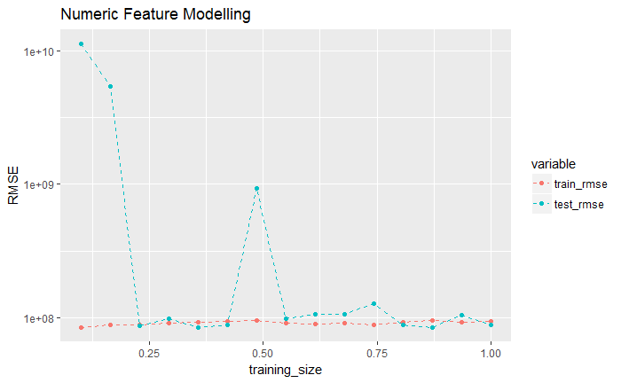

```r
ggplot(rmse_task1, aes(x = training_size, y=RMSE, group = variable, color = variable)) +
  geom_line(linetype = "dashed") +
  geom_point() + scale_y_log10() +
ggtitle("Numeric Feature Modelling")
#print(colnames(df_numeric_train))
print(paste("Best mean test RMSE value observed for numeric features:", min(training_size_stats$test_rmse), sep = " "))
```

```
[1] "Best mean test RMSE value observed for numeric features: 83858702.8399003"
```

**Q**: List the numeric variables you used.

**A**: [1] “Runtime” “imdbRating” “imdbVotes” “tomatoMeter” “tomatoRating” “tomatoReviews”  
[7] “tomatoFresh” “tomatoRotten” “tomatoUserMeter” “tomatoUserRating” “tomatoUserReviews” “Budget”  
[13]“Released_year” “Metascore” “Gross” (Target)

**Q**: What is the best mean test RMSE value you observed, and at what training set size? **A**: Best mean test RMSE value observed for numeric features: 83858702.8399003, training_size is 87.15%

## 2. Feature transformations

Try to improve the prediction quality from **Task 1** as much as possible by adding feature transformations of the numeric variables. Explore both numeric transformations such as power transforms and non-numeric transformations of the numeric variables like binning (e.g. `is_budget_greater_than_3M`).

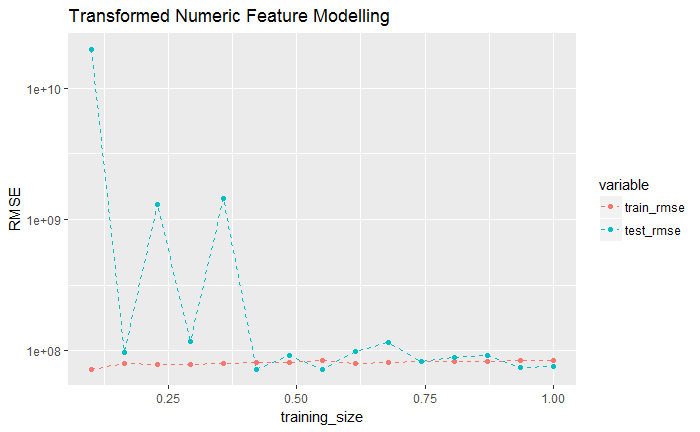

```r
for(i in 1:length(training_size)){
  resutls_transform <- RMSE(temp, training_size[i])
  training_size_stats_tranform7[i,] <- c(training_size[i], resutls_transform[1], resutls_transform[2])
}
for(i in 1:length(training_size)){
  resutls_transform <- RMSE(temp, training_size[i])
  training_size_stats_tranform7[i,] <- c(training_size[i], resutls_transform[1], resutls_transform[2])
}
rmse_task2 <- melt(training_size_stats_tranform7[,c('training_size', "train_rmse", "test_rmse")], id = "training_size")
colnames(rmse_task2) <- c("training_size", "variable", "RMSE")
colnames(rmse_task2) <- c("training_size", "variable", "RMSE")
ggplot(rmse_task2, aes(x = training_size, y=RMSE, group = variable, color = variable)) +
  geom_line(linetype = "dashed") +
  geom_point() + scale_y_log10() +
ggtitle("Transformed Numeric Feature Modelling")
print(paste("Best mean test RMSE value observed for numeric features:", min(training_size_stats_tranform7$test_rmse), sep = " "))
```

```
[1] "Best mean test RMSE value observed for numeric features: 71969667.8478177"
```

**Q**: Explain which transformations you used and why you chose them.

**A**: 1. Binning: Binning’s really only a good idea when you’d expect a discontinuity in the response at the cut-points. Runtime although a real valued feature there are discontinuities i.e Runtime generally fall in to few buckets like short, medium, long, very long e.t.c

```
  2. One-hot Encoding: In the EDA from Project 1, we have observed distinct distributions of Budget, hence I created 5 categories of budget i.e. Low Budget, High Budget, Large Budget e.t.c as one-hot encoded variables

  3. Power Transforming: I have tested log, squared and power transformations on all the numeric variables. By looking at plots of features like Budget and looking at the significane of transformed features, I have filtered them to a set of 11 new features.
```

**Q**: How did the RMSE change compared to Task 1?